# R_Assignment_Schuller

Colin Schuller

2024-03-09

# Loading Tidyverse and files to the environment

```r
library(tidyverse)
fang_et_al_genotypes <- read.delim("https://github.com/EEOB-BioData/BCB546_Spring2024/blob/main/assignments/UNIX_Assignment/fang_et_al_genotypes.txt?raw=true", header = TRUE, sep = "\t")

snp_position <- read.delim("https://github.com/EEOB-BioData/BCB546_Spring2024/blob/main/assignments/UNIX_Assignment/snp_position.txt?raw=true", header = TRUE, sep = "\t")
```

# File Information

```r
dim(fang_et_al_genotypes)
```

```
## [1] 2782  986
```

```r
dim(snp_position)
```

```
## [1] 983  15
```

```r
paste0("This file, fang_et_al, has ", dim(fang_et_al_genotypes)[1], " rows and ", dim(fang_et_al_genotypes)[2], " columns.")
```

```
## [1] "This file, fang_et_al, has 2782 rows and 986 columns."
```

```r
paste0("This file, snp_position, has ", dim(snp_position)[1], " rows and ", dim(snp_position)[2], " columns.")
```

```
## [1] "This file, snp_position, has 983 rows and 15 columns."
```

```r
str(fang_et_al_genotypes[, 1:10])
```

```
## 'data.frame':    2782 obs. of  10 variables:
##  $ Sample_ID: chr  "SL-15" "SL-16" "SL-11" "SL-12" ...
##  $ JG_OTU   : chr  "T-aust-1" "T-aust-2" "T-brav-1" "T-brav-2" ...
##  $ Group    : chr  "TRIPS" "TRIPS" "TRIPS" "TRIPS" ...
##  $ abph1.20 : chr  "?/?" "?/?" "?/?" "?/?" ...
##  $ abph1.22 : chr  "?/?" "?/?" "?/?" "?/?" ...
##  $ ae1.3    : chr  "T/T" "T/T" "T/T" "T/T" ...
##  $ ae1.4    : chr  "G/G" "?/?" "G/G" "G/G" ...
##  $ ae1.5    : chr  "T/T" "T/T" "T/T" "T/T" ...
##  $ an1.4    : chr  "C/C" "C/C" "?/?" "C/C" ...
##  $ ba1.6    : chr  "?/?" "A/G" "G/G" "G/G" ...
```

```r
str(snp_position[, 1:10])
```

```
## 'data.frame':    983 obs. of  10 variables:
##  $ SNP_ID              : chr  "abph1.20" "abph1.22" "ae1.3" "ae1.4" ...
##  $ cdv_marker_id       : int  5976 5978 6605 6606 6607 5982 3463 3466 5983 5985 ...
##  $ Chromosome          : chr  "2" "2" "5" "5" ...
##  $ Position            : chr  "27403404" "27403892" "167889790" "167889682" ...
##  $ alt_pos             : chr  "" "" "" "" ...
##  $ mult_positions      : chr  "" "" "" "" ...
##  $ amplicon            : chr  "abph1" "abph1" "ae1" "ae1" ...
##  $ cdv_map_feature.name: chr  "AB042260" "AB042260" "ae1" "ae1" ...
##  $ gene                : chr  "abph1" "abph1" "ae1" "ae1" ...
##  $ candidate.random    : chr  "candidate" "candidate" "candidate" "candidate" ...
```

# Maize SNP data

Grab the important maize genotypes for later

```r
maize_genotypes <- fang_et_al_genotypes %>% filter(grepl("ZMMIL|ZMMLR|ZMMMR", Group))
```

Cut out the required snp columns for analysis

```r
snp_position_cut <- snp_position[,c(1,3,4)]
```

Transposed the data

```r
transposed_maize_genotypes <- as.data.frame(t(maize_genotypes))
```

Reformat the transposed file and remove the first 3 rows as they have data not suitable for merging the files in later steps.

```r
transposed_maize_genotypes_reformatted <- transposed_maize_genotypes %>% rownames_to_column(var="Sample_ID")

transposed_maize_genotypes_reformatted <- transposed_maize_genotypes_reformatted[-1:-3,]

names(transposed_maize_genotypes_reformatted)[1] <-"SNP_ID"
```

Joining the two files together(x2), one for the ‘?’ missing data symbol and one for the ‘-’ missing data symbol for later

```r
maize_genotypes_snp_merged_q <- inner_join(snp_position_cut,transposed_maize_genotypes_reformatted, by = "SNP_ID")

maize_genotypes_snp_merged_d <- inner_join(snp_position_cut,transposed_maize_genotypes_reformatted, by = "SNP_ID")
```

Changing all the ‘?’ to ‘-’ for later

```r
maize_genotypes_snp_merged_d[maize_genotypes_snp_merged_d == "?/?"] <- "-/-"
```

Organizing by increasing snp position with ‘?’ for missing data

```r
maize_genotypes_snp_merged_q_sorted_increasing <- maize_genotypes_snp_merged_q[order(as.numeric(maize_genotypes_snp_merged_q$Position)),]
```

Organizing by decreasing snp position with ‘-’ for missing data

```r
maize_genotypes_snp_merged_d_sorted_decreasing <- maize_genotypes_snp_merged_d[order(as.numeric(maize_genotypes_snp_merged_d$Position), decreasing = TRUE),]
```

Organizing the increasing and decreasing position chromosome data by moving each chromosome to their own file

```r
maize_chr_1_increasing <- maize_genotypes_snp_merged_q_sorted_increasing %>% filter(grepl("1$", Chromosome))
maize_chr_2_increasing <- maize_genotypes_snp_merged_q_sorted_increasing %>% filter(grepl("2$", Chromosome))
maize_chr_3_increasing <- maize_genotypes_snp_merged_q_sorted_increasing %>% filter(grepl("3$", Chromosome))
maize_chr_4_increasing <- maize_genotypes_snp_merged_q_sorted_increasing %>% filter(grepl("4$", Chromosome))
maize_chr_5_increasing <- maize_genotypes_snp_merged_q_sorted_increasing %>% filter(grepl("5$", Chromosome))
maize_chr_6_increasing <- maize_genotypes_snp_merged_q_sorted_increasing %>% filter(grepl("6$", Chromosome))
maize_chr_7_increasing <- maize_genotypes_snp_merged_q_sorted_increasing %>% filter(grepl("7$", Chromosome))
maize_chr_8_increasing <- maize_genotypes_snp_merged_q_sorted_increasing %>% filter(grepl("8$", Chromosome))
maize_chr_9_increasing <- maize_genotypes_snp_merged_q_sorted_increasing %>% filter(grepl("9$", Chromosome))
maize_chr_10_increasing <- maize_genotypes_snp_merged_q_sorted_increasing %>% filter(grepl("10$", Chromosome))

maize_chr_1_decreasing <- maize_genotypes_snp_merged_d_sorted_decreasing %>% filter(grepl("1$", Chromosome))
maize_chr_2_decreasing <- maize_genotypes_snp_merged_d_sorted_decreasing %>% filter(grepl("2$", Chromosome))
maize_chr_3_decreasing <- maize_genotypes_snp_merged_d_sorted_decreasing %>% filter(grepl("3$", Chromosome))
maize_chr_4_decreasing <- maize_genotypes_snp_merged_d_sorted_decreasing %>% filter(grepl("4$", Chromosome))
maize_chr_5_decreasing <- maize_genotypes_snp_merged_d_sorted_decreasing %>% filter(grepl("5$", Chromosome))
maize_chr_6_decreasing <- maize_genotypes_snp_merged_d_sorted_decreasing %>% filter(grepl("6$", Chromosome))
maize_chr_7_decreasing <- maize_genotypes_snp_merged_d_sorted_decreasing %>% filter(grepl("7$", Chromosome))
maize_chr_8_decreasing <- maize_genotypes_snp_merged_d_sorted_decreasing %>% filter(grepl("8$", Chromosome))
maize_chr_9_decreasing <- maize_genotypes_snp_merged_d_sorted_decreasing %>% filter(grepl("9$", Chromosome))
maize_chr_10_decreasing<- maize_genotypes_snp_merged_d_sorted_decreasing %>% filter(grepl("10$", Chromosome))
```

# Teosinte SNP data

```r
teosinte_genotypes <- fang_et_al_genotypes %>% filter(grepl("ZMPBA|ZMPIL|ZMPJA", Group))
```

Transposing the data

```r
transposed_teosinte_genotypes <- as.data.frame(t(teosinte_genotypes))
```

Reformat the transposed file and remove the first 3 rows as they have data not suitable for merging the files in later steps.

```r
transposed_teosinte_genotypes_reformatted <- transposed_teosinte_genotypes %>% rownames_to_column(var="Sample_ID")

transposed_teosinte_genotypes_reformatted <- transposed_teosinte_genotypes_reformatted[-1:-3,]

names(transposed_teosinte_genotypes_reformatted)[1] <-"SNP_ID"
```

Joining the two files together(x2), one for the ‘?’ missing data symbol and one for the ‘-’ missing data symbol for later

```r
teosinte_genotypes_snp_merged_q <- inner_join(snp_position_cut,transposed_teosinte_genotypes_reformatted, by = "SNP_ID")

teosinte_genotypes_snp_merged_d <- inner_join(snp_position_cut,transposed_teosinte_genotypes_reformatted, by = "SNP_ID")
```

Changing all the ‘?’ to ‘-’ for later

```r
teosinte_genotypes_snp_merged_d[teosinte_genotypes_snp_merged_d == "?/?"] <- "-/-"
```

Organizing by increasing snp position with ‘?’ for missing data

```r
teosinte_genotypes_snp_merged_q_sorted_increasing <- teosinte_genotypes_snp_merged_q[order(as.numeric(teosinte_genotypes_snp_merged_q$Position)),]
```

Organizing by decreasing snp position with ‘-’ for missing data

```r
teosinte_genotypes_snp_merged_d_sorted_decreasing <- teosinte_genotypes_snp_merged_d[order(as.numeric(maize_genotypes_snp_merged_d$Position), decreasing = TRUE),]
```

Organizing the increasing and decreasing position chromosome data by moving each chromosome to their own file

```r
teosinte_chr_1_increasing <- teosinte_genotypes_snp_merged_q_sorted_increasing %>% filter(grepl("1$", Chromosome))
teosinte_chr_2_increasing <- teosinte_genotypes_snp_merged_q_sorted_increasing %>% filter(grepl("2$", Chromosome))
teosinte_chr_3_increasing <- teosinte_genotypes_snp_merged_q_sorted_increasing %>% filter(grepl("3$", Chromosome))
teosinte_chr_4_increasing <- teosinte_genotypes_snp_merged_q_sorted_increasing %>% filter(grepl("4$", Chromosome))
teosinte_chr_5_increasing <- teosinte_genotypes_snp_merged_q_sorted_increasing %>% filter(grepl("5$", Chromosome))
teosinte_chr_6_increasing <- teosinte_genotypes_snp_merged_q_sorted_increasing %>% filter(grepl("6$", Chromosome))
teosinte_chr_7_increasing <- teosinte_genotypes_snp_merged_q_sorted_increasing %>% filter(grepl("7$", Chromosome))
teosinte_chr_8_increasing <- teosinte_genotypes_snp_merged_q_sorted_increasing %>% filter(grepl("8$", Chromosome))
teosinte_chr_9_increasing <- teosinte_genotypes_snp_merged_q_sorted_increasing %>% filter(grepl("9$", Chromosome))
teosinte_chr_10_increasing <- teosinte_genotypes_snp_merged_q_sorted_increasing %>% filter(grepl("10$", Chromosome))

teosinte_chr_1_decreasing <- teosinte_genotypes_snp_merged_d_sorted_decreasing %>% filter(grepl("1$", Chromosome))
teosinte_chr_2_decreasing <- teosinte_genotypes_snp_merged_d_sorted_decreasing %>% filter(grepl("2$", Chromosome))
teosinte_chr_3_decreasing <- teosinte_genotypes_snp_merged_d_sorted_decreasing %>% filter(grepl("3$", Chromosome))
teosinte_chr_4_decreasing <- teosinte_genotypes_snp_merged_d_sorted_decreasing %>% filter(grepl("4$", Chromosome))
teosinte_chr_5_decreasing <- teosinte_genotypes_snp_merged_d_sorted_decreasing %>% filter(grepl("5$", Chromosome))
teosinte_chr_6_decreasing <- teosinte_genotypes_snp_merged_d_sorted_decreasing %>% filter(grepl("6$", Chromosome))
teosinte_chr_7_decreasing <- teosinte_genotypes_snp_merged_d_sorted_decreasing %>% filter(grepl("7$", Chromosome))
teosinte_chr_8_decreasing <- teosinte_genotypes_snp_merged_d_sorted_decreasing %>% filter(grepl("8$", Chromosome))
teosinte_chr_9_decreasing <- teosinte_genotypes_snp_merged_d_sorted_decreasing %>% filter(grepl("9$", Chromosome))
teosinte_chr_10_decreasing<- teosinte_genotypes_snp_merged_d_sorted_decreasing %>% filter(grepl("10$", Chromosome))
```

# Data Visualization

Maize and Teosinte SNPs on each chromosome

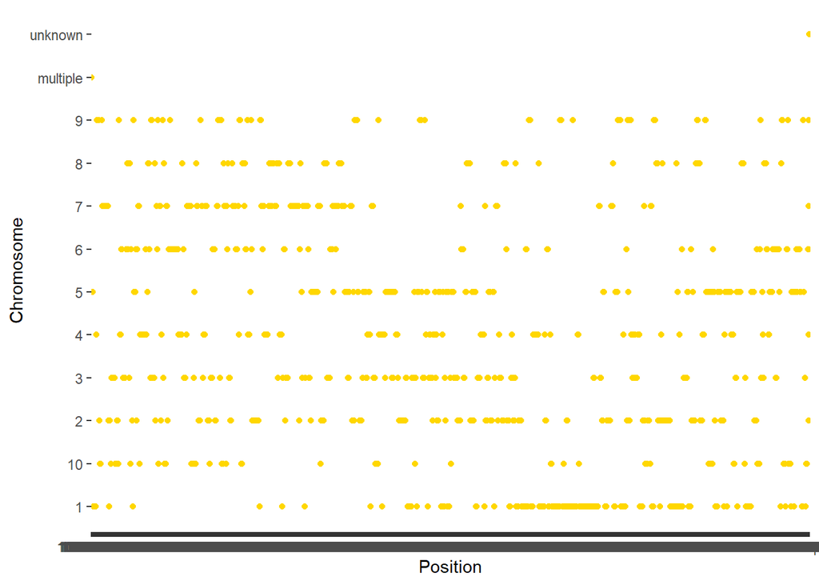

```r
ggplot(maize_genotypes_snp_merged_q, aes(x=Position, y=Chromosome)) + geom_point(col = "gold")
```

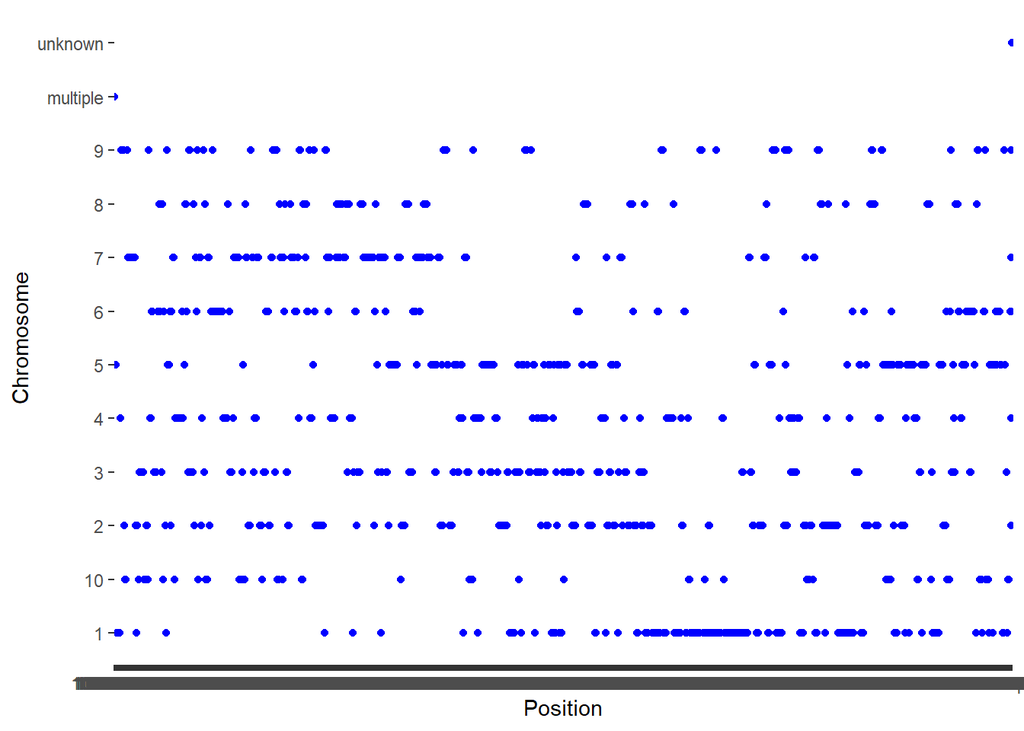

```r
ggplot(teosinte_genotypes_snp_merged_q, aes(x=Position, y=Chromosome)) + geom_point(col = "blue")
```

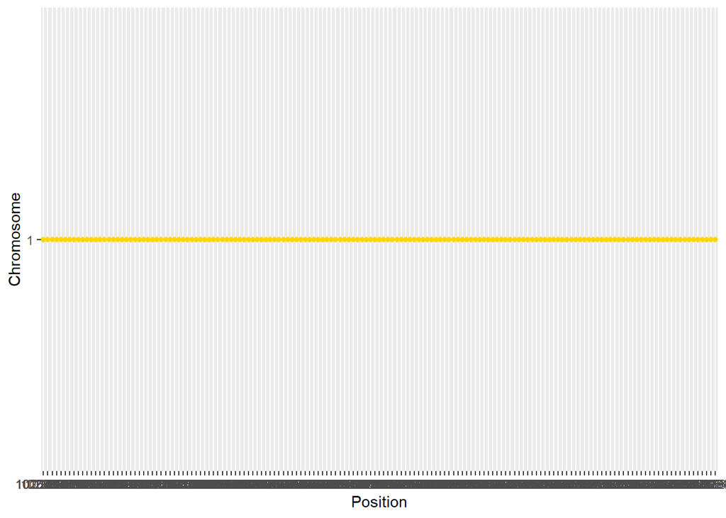

```r
ggplot(maize_chr_1_increasing, aes(x=Position, y=Chromosome)) + geom_point(col = "gold")
```

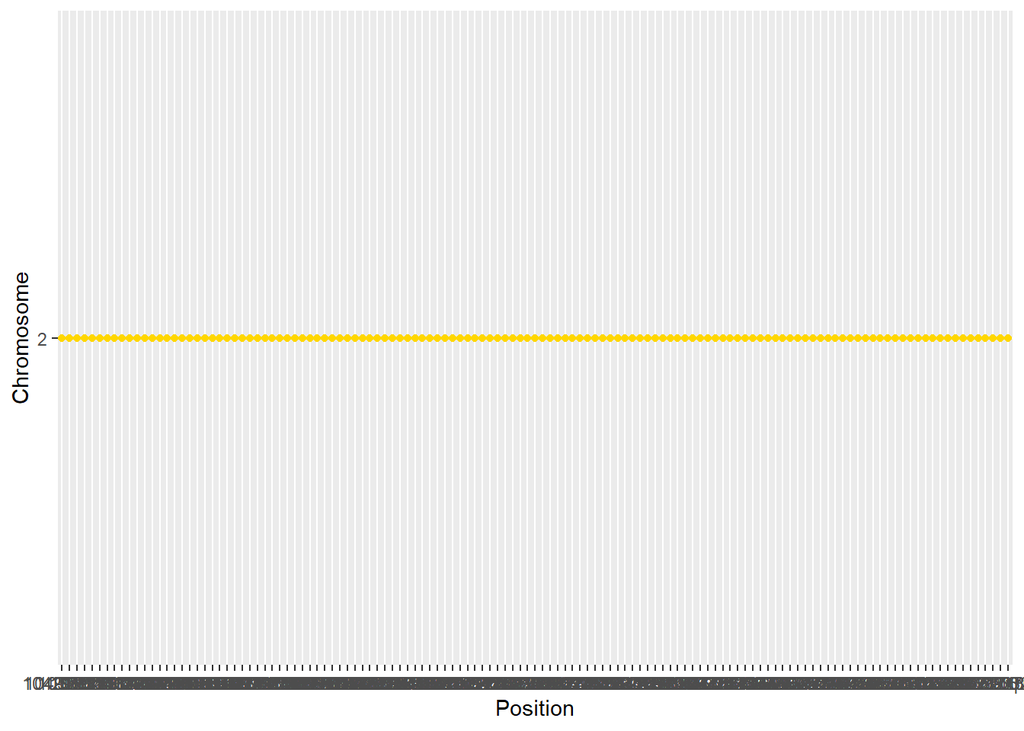

```r
ggplot(maize_chr_2_increasing, aes(x=Position, y=Chromosome)) + geom_point(col = "gold")
```

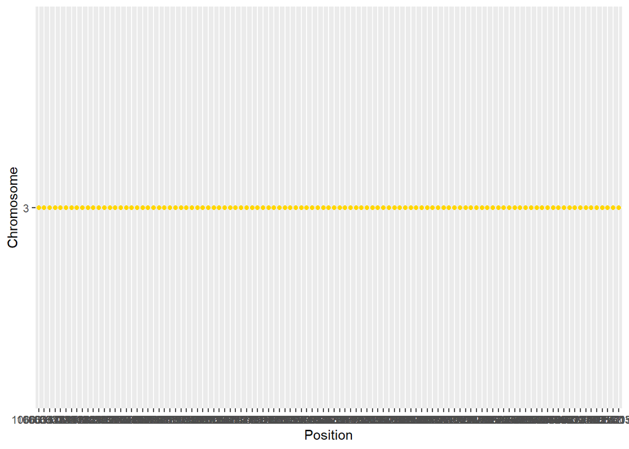

```r
ggplot(maize_chr_3_increasing, aes(x=Position, y=Chromosome)) + geom_point(col = "gold")
```

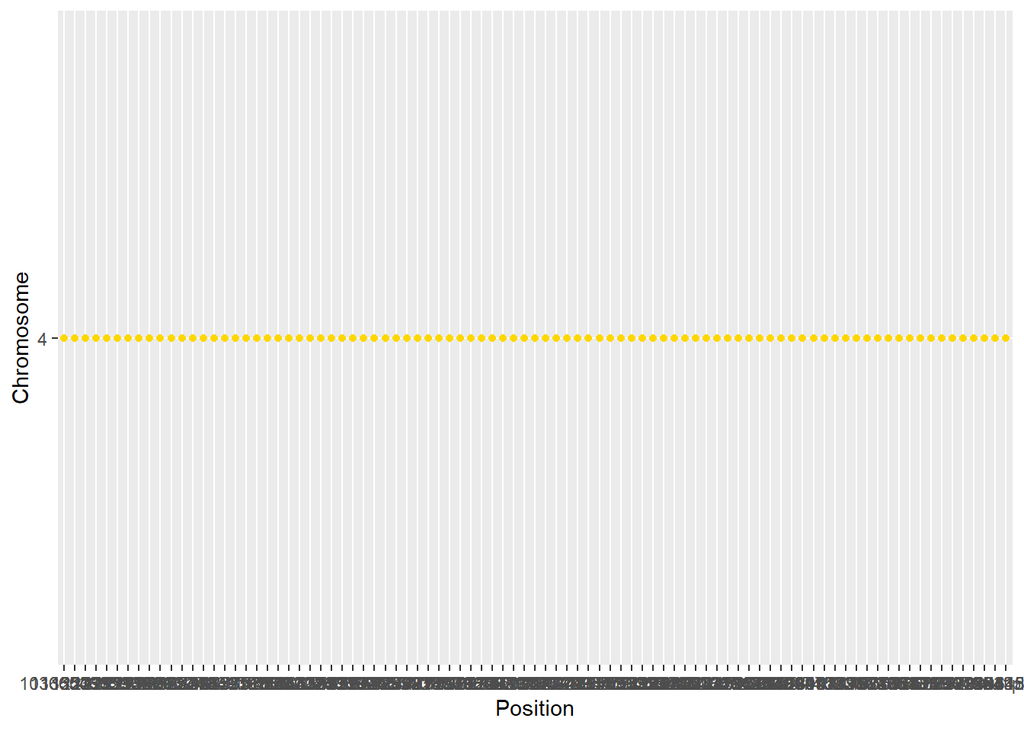

```r
ggplot(maize_chr_4_increasing, aes(x=Position, y=Chromosome)) + geom_point(col = "gold")
```

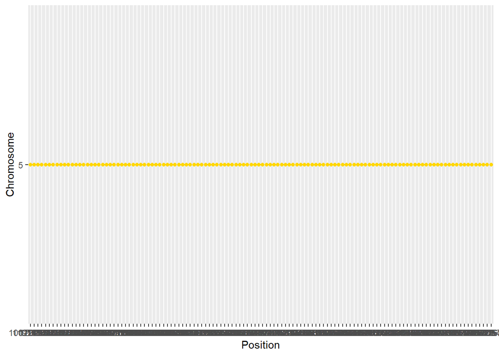

```r
ggplot(maize_chr_5_increasing, aes(x=Position, y=Chromosome)) + geom_point(col = "gold")
```

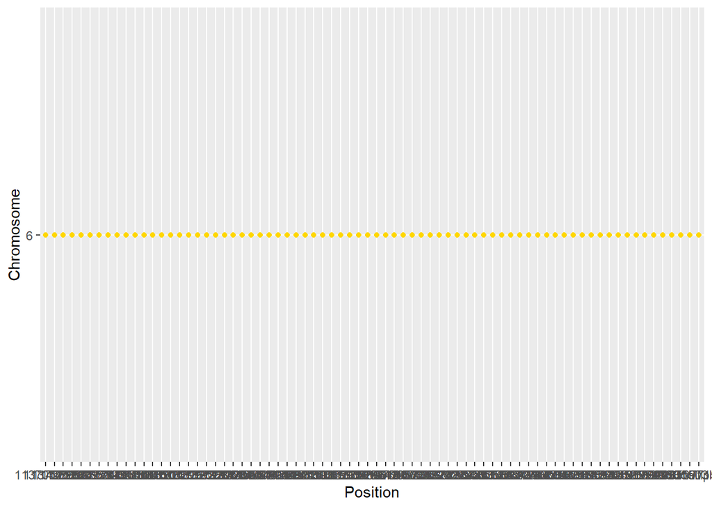

```r
ggplot(maize_chr_6_increasing, aes(x=Position, y=Chromosome)) + geom_point(col = "gold")
```

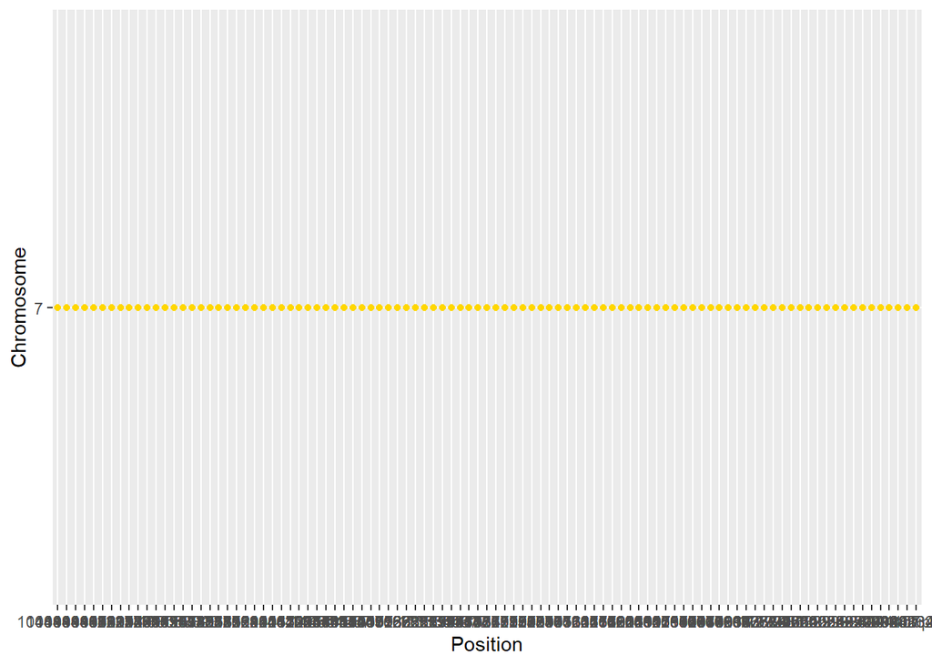

```r
ggplot(maize_chr_7_increasing, aes(x=Position, y=Chromosome)) + geom_point(col = "gold")
```

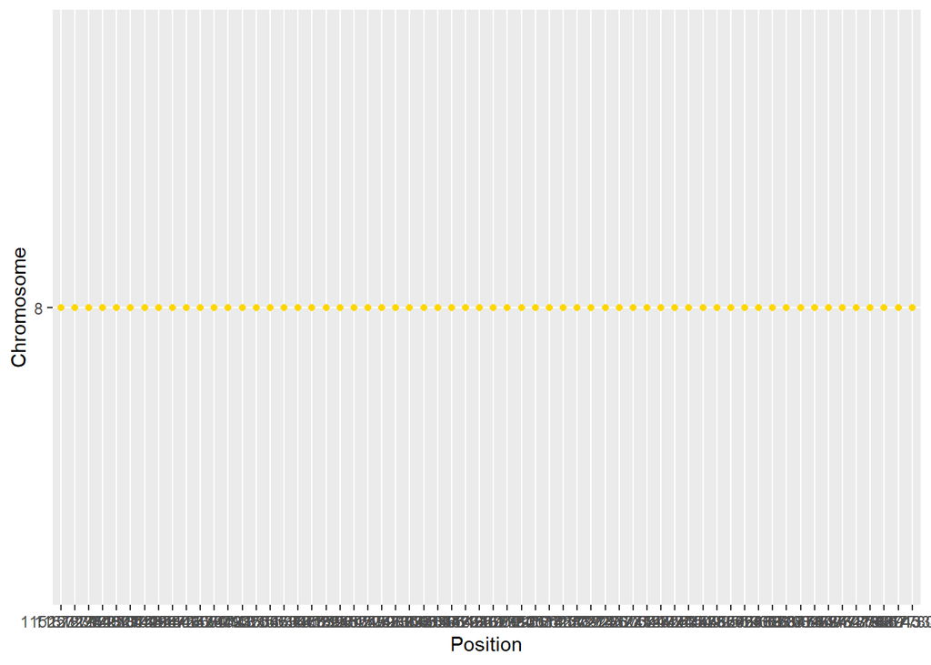

```r
ggplot(maize_chr_8_increasing, aes(x=Position, y=Chromosome)) + geom_point(col = "gold")
```

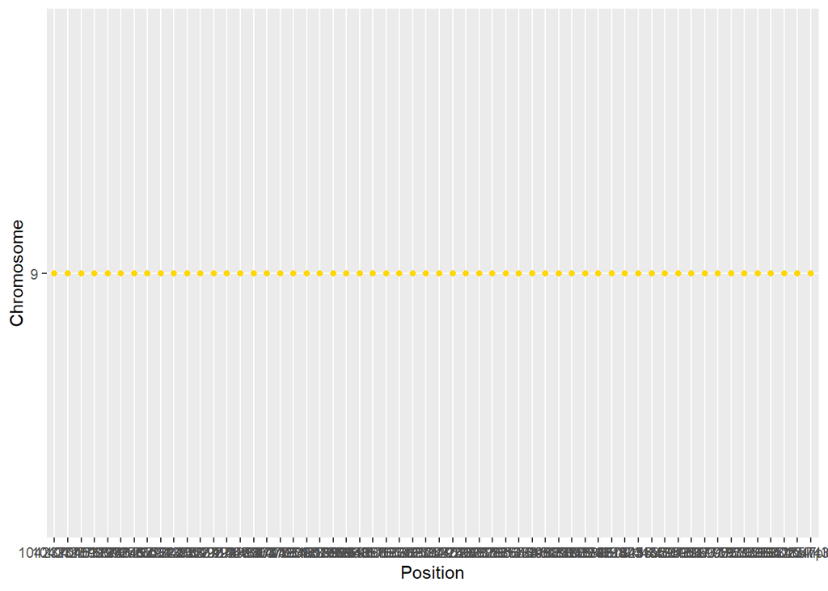

```r
ggplot(maize_chr_9_increasing, aes(x=Position, y=Chromosome)) + geom_point(col = "gold")
```

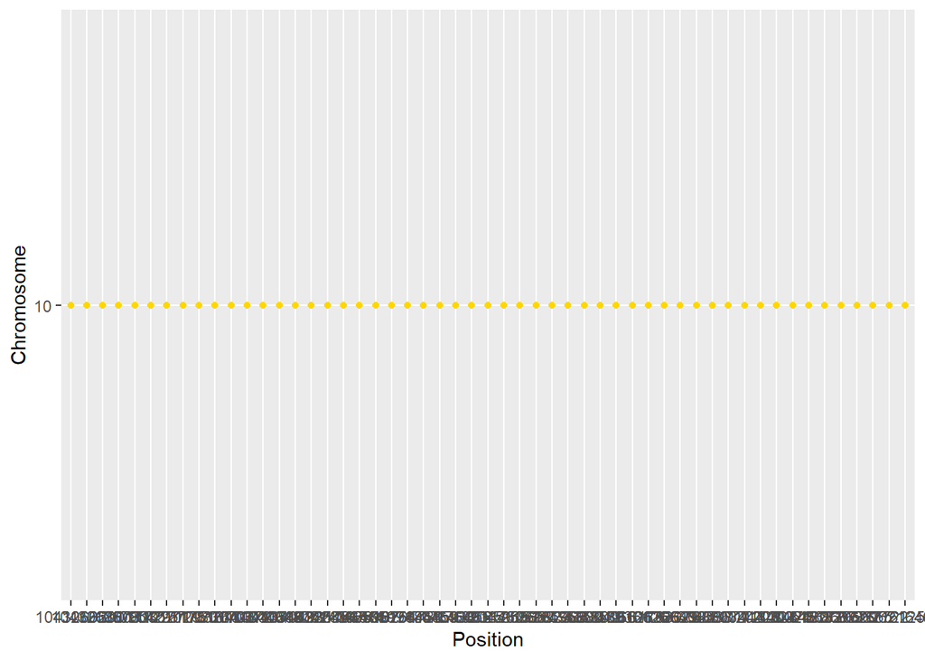

```r
ggplot(maize_chr_10_increasing, aes(x=Position, y=Chromosome)) + geom_point(col = "gold")
```

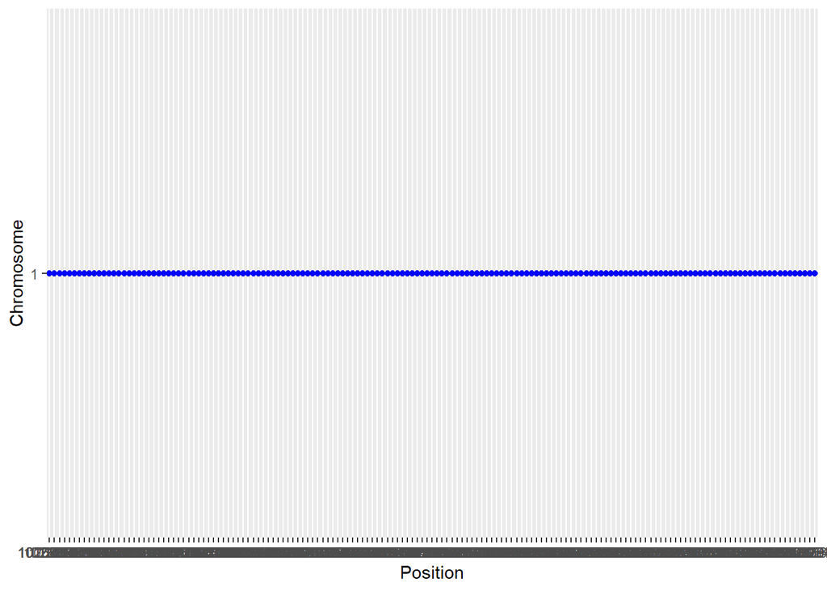

```r
ggplot(teosinte_chr_1_increasing, aes(x=Position, y=Chromosome)) + geom_point(col = "blue")
```

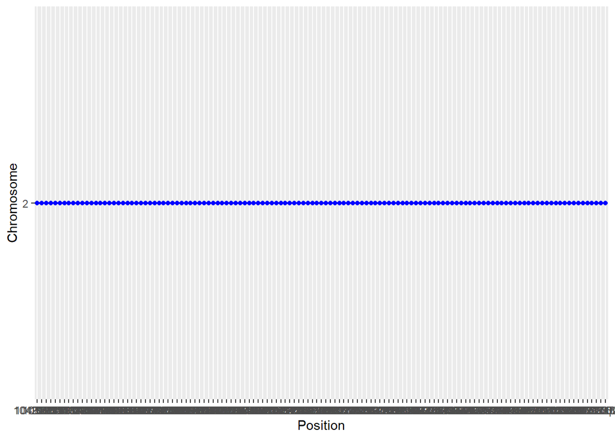

```r
ggplot(teosinte_chr_2_increasing, aes(x=Position, y=Chromosome)) + geom_point(col = "blue")
```

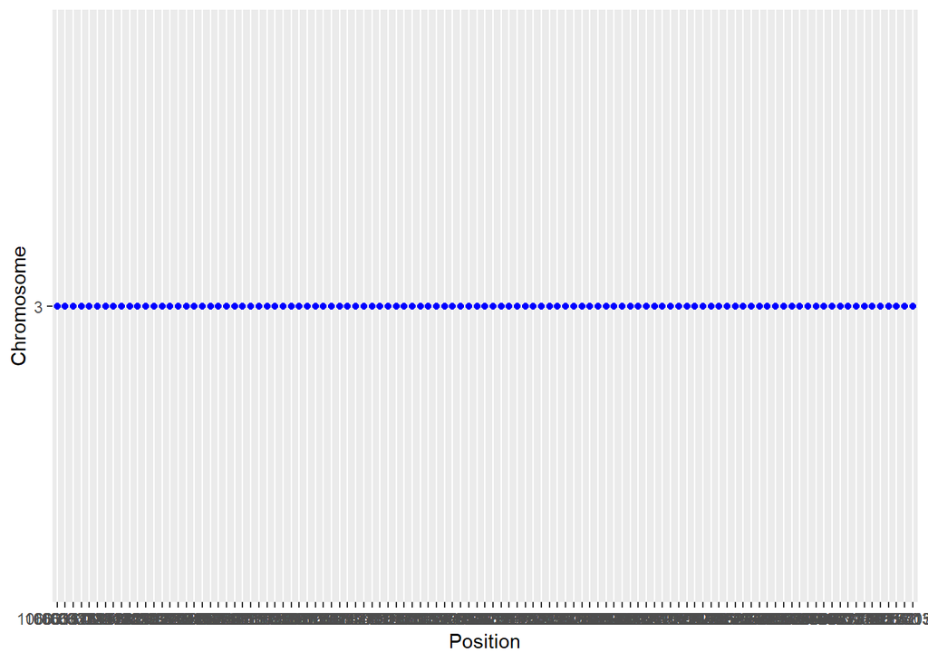

```r
ggplot(teosinte_chr_3_increasing, aes(x=Position, y=Chromosome)) + geom_point(col = "blue")
```

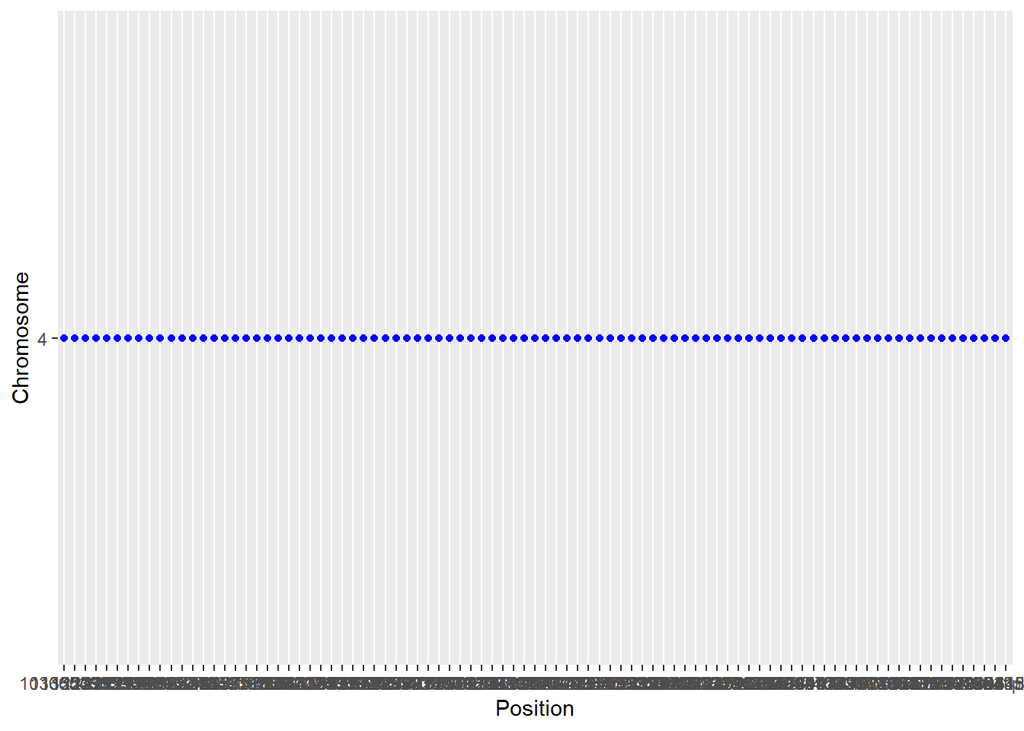

```r
ggplot(teosinte_chr_4_increasing, aes(x=Position, y=Chromosome)) + geom_point(col = "blue")
```

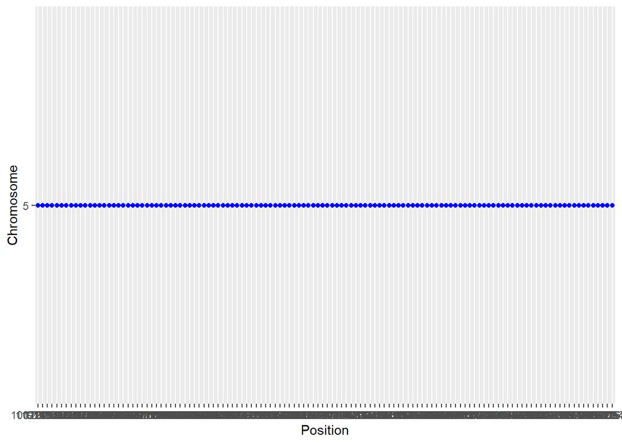

```r
ggplot(teosinte_chr_5_increasing, aes(x=Position, y=Chromosome)) + geom_point(col = "blue")
```

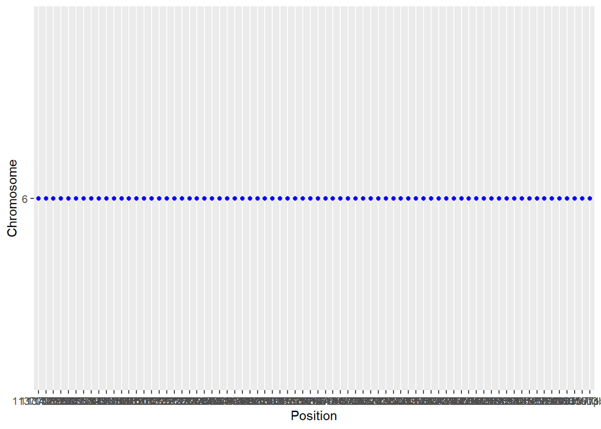

```r
ggplot(teosinte_chr_6_increasing, aes(x=Position, y=Chromosome)) + geom_point(col = "blue")
```

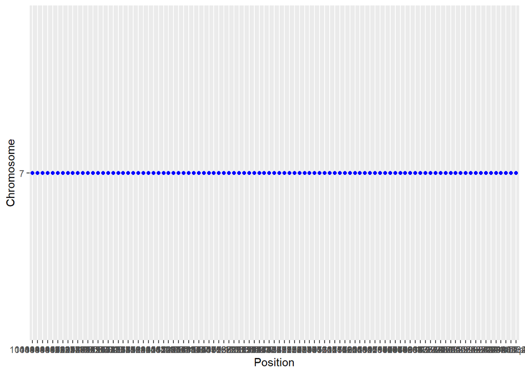

```r
ggplot(teosinte_chr_7_increasing, aes(x=Position, y=Chromosome)) + geom_point(col = "blue")
```

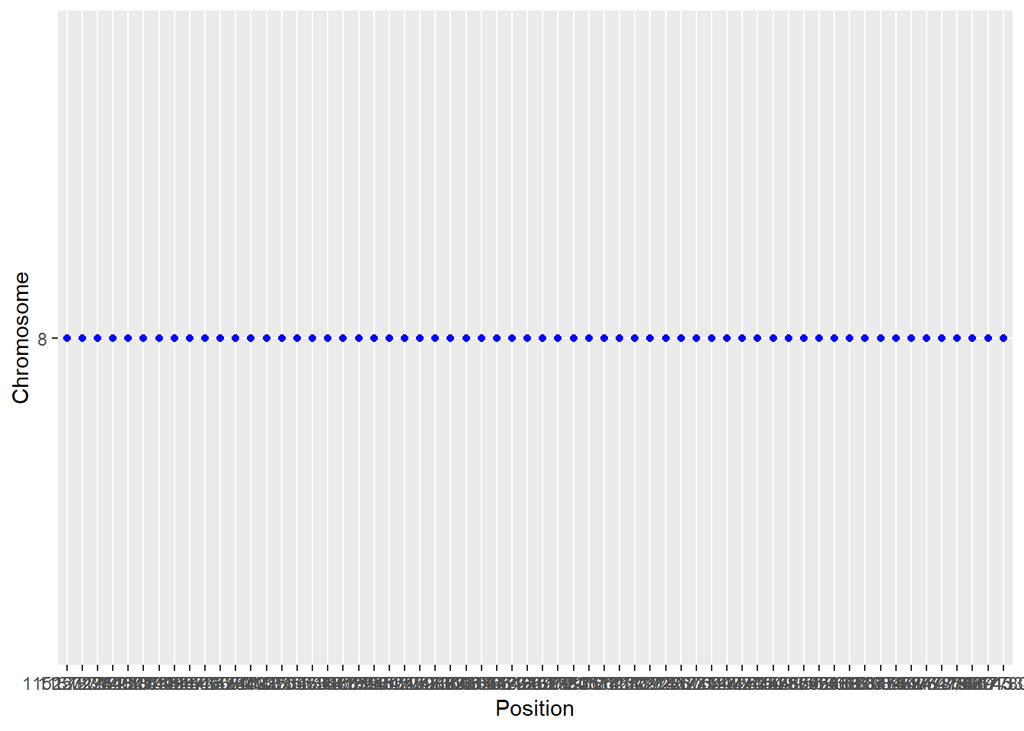

```r
ggplot(teosinte_chr_8_increasing, aes(x=Position, y=Chromosome)) + geom_point(col = "blue")
```

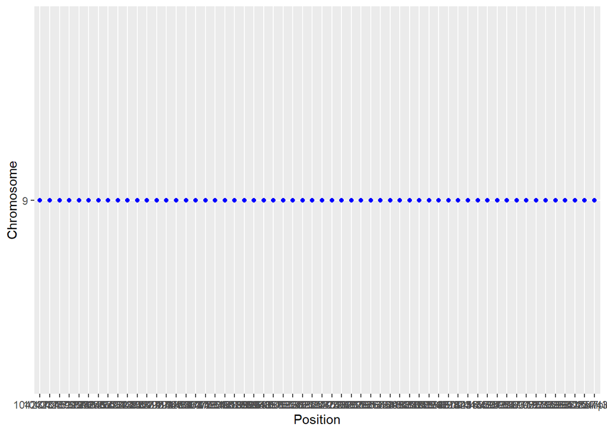

```r
ggplot(teosinte_chr_9_increasing, aes(x=Position, y=Chromosome)) + geom_point(col = "blue")
```

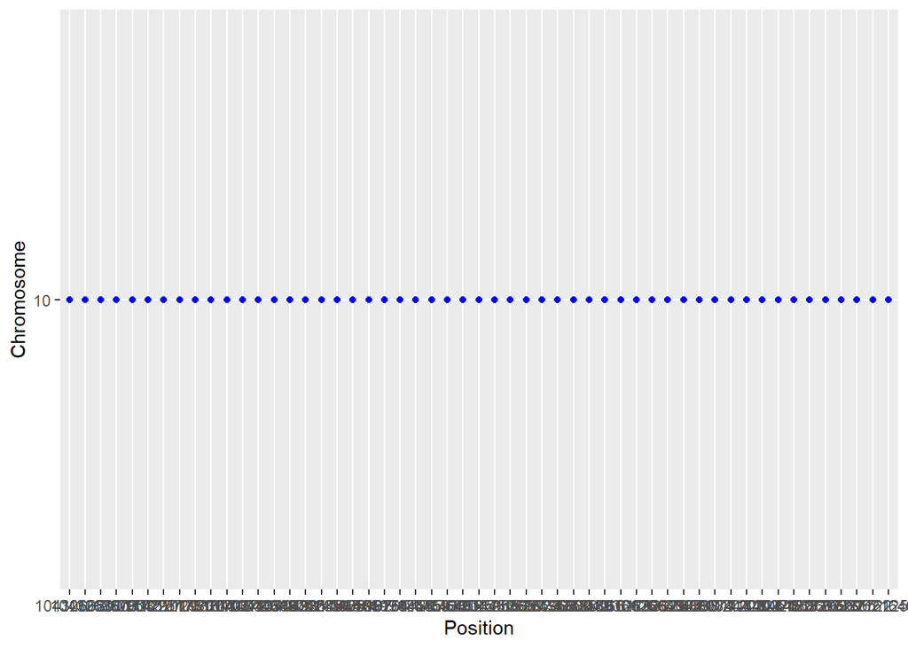

```r
ggplot(teosinte_chr_10_increasing, aes(x=Position, y=Chromosome)) + geom_point(col = "blue")
```

```r
#Based on the SNP data between Maize and Teosinte, there is no difference in SNP distribution and position while visually assessing the data.
```

Maize and Teosinte missing data and amount of heterzygosity

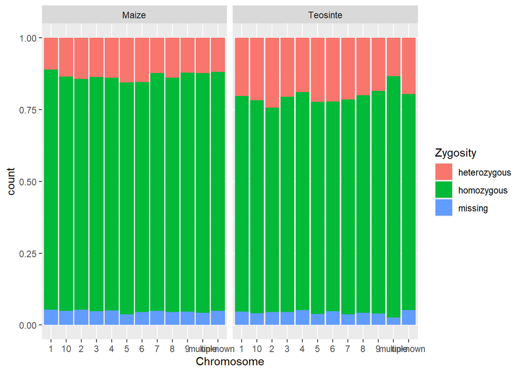

```r
newcolumn_maize <- pivot_longer(maize_genotypes_snp_merged_q, cols = !1:3, names_to = "Genes")
newcolumn_maize$Zygosity <- case_when(newcolumn_maize$value == "A/A" ~ "homozygous", newcolumn_maize$value == "C/C" ~ "homozygous", newcolumn_maize$value == "G/G" ~ "homozygous", newcolumn_maize$value == "T/T" ~ "homozygous", newcolumn_maize$value == "?/?" ~ "missing", .default = "heterozygous" )

newcolumn_teosinte <- pivot_longer(teosinte_genotypes_snp_merged_q, cols = !1:3, names_to = "Genes")
newcolumn_teosinte$Zygosity <- case_when(newcolumn_teosinte$value == "A/A" ~ "homozygous", newcolumn_teosinte$value == "C/C" ~ "homozygous", newcolumn_teosinte$value == "G/G" ~ "homozygous", newcolumn_teosinte$value == "T/T" ~ "homozygous", newcolumn_teosinte$value == "?/?" ~ "missing", .default = "heterozygous" )

newcolumn_maize$species <- "Maize"
newcolumn_teosinte$species <- "Teosinte"

combined_column_table <- rbind(newcolumn_maize, newcolumn_teosinte)

ggplot(data= combined_column_table) + geom_bar(mapping = aes(x = Chromosome, fill=Zygosity), position = "fill") + facet_wrap(~species)
```

```r
#Missing data and amount of heterozygosity
```

Visualizing snp type per chromosome

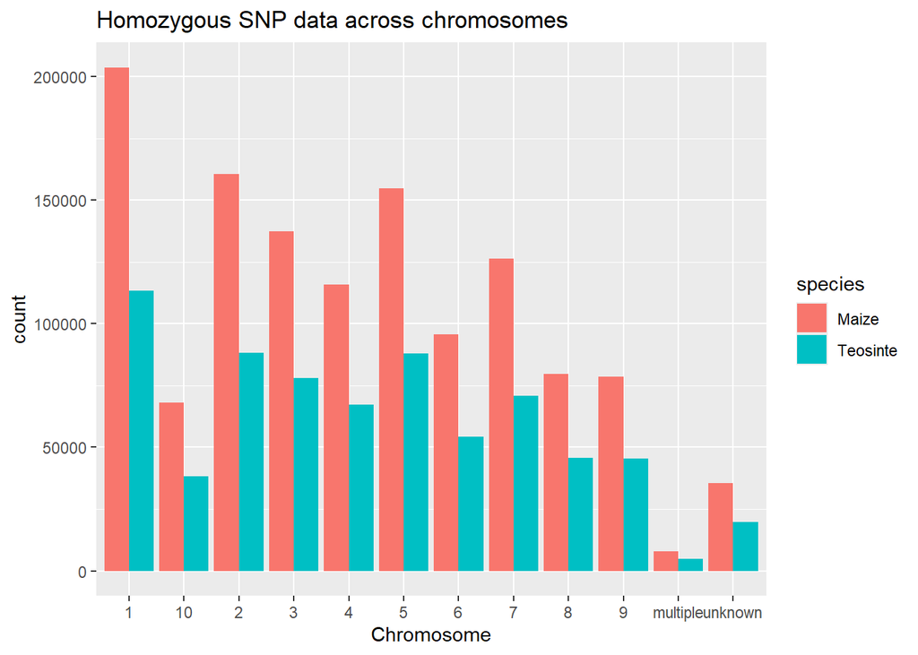

```r
#Mapping homozygous snps per chromosome for maize and teosinte
combined_column_table_homozygous <- combined_column_table %>% filter(grepl("homozygous", Zygosity))

ggplot(data= combined_column_table_homozygous) + geom_bar(mapping = aes(x = Chromosome, fill=species), position = "dodge") + ggtitle("Homozygous SNP data across chromosomes")
```

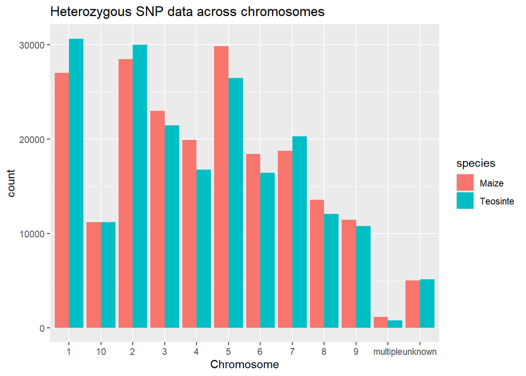

```r
#Mapping heterozygous snps per chromosome for maize and teosinte
combined_column_table_heterozygous <- combined_column_table %>% filter(grepl("heterozygous", Zygosity))

ggplot(data= combined_column_table_heterozygous) + geom_bar(mapping = aes(x = Chromosome, fill=species), position = "dodge") + ggtitle("Heterozygous SNP data across chromosomes")
```

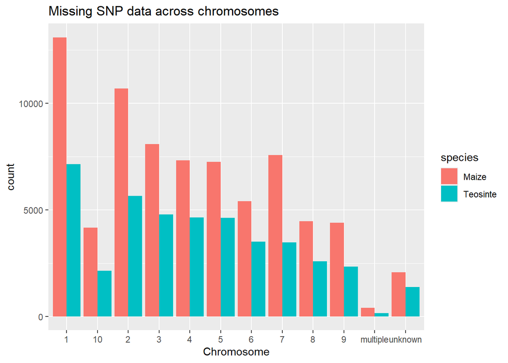

```r
#Mapping missing snp data across chromosomes for maize and teosinte
combined_column_table_missing <- combined_column_table %>% filter(grepl("missing", Zygosity))

ggplot(data= combined_column_table_missing) + geom_bar(mapping = aes(x = Chromosome, fill=species), position = "dodge") + ggtitle("Missing SNP data across chromosomes")
```